# LSP Bayesian Regression on Linearized Double-logistic LSP

Matthew Shisler

2022-05-19

```r
library(tidyverse)
source("utility_functions.R")
```

We will attempt to understand that effects of applying a Bayesian linear regression on the linearization (wrt to the parameter vector, $\theta$) of the double logistic function.

This simulation will involve different levels for three factors. 1) The magnitude of variation for each element of $\theta$. (3 levels) 2) The magnitude of the measurement noise (i.e. error variance), $\sigma^2$. (2 levels) 3) The number of observations per year. (3 levels)

We simulate 1000 evi2 curves for each combination of factor levels.

We aggregate these 1000 evi2 curves and fit a frequentist non-linear regression to construct an “average model” estimate of the parameter vector, $\theta_0$.

We linearize the double logistic function wrt to $\theta$ centered on the $\theta$ estimate from the average model. This constructs the basis function “data matrix.”

For each simulated evi2 curve at a given combination of factor levels we fit a Bayesian linear regression to the linearized double-logistic function where the parameters are basis function coefficients $b=(\theta-\theta_0)$. We assume an idealized case where we know the error variance and covariance matrix for $\theta$ (the magnitudes of which are treated as different factor levels).

Finally, we construct 95% credible intervals for each evi2 curve using the posterior distribution for the Bayesian linear regression.

For results, we compute the coverage and widths of the 95% credible intervals and the the deviations of the $\theta$ estimates from their true value. (estimated value - true value).

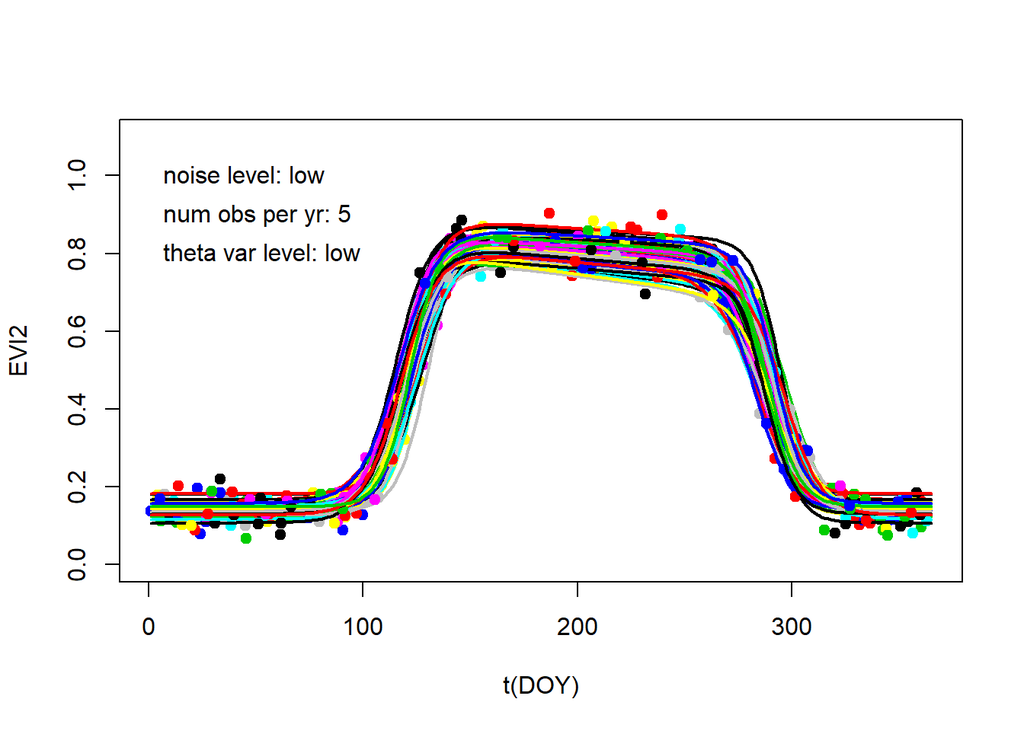

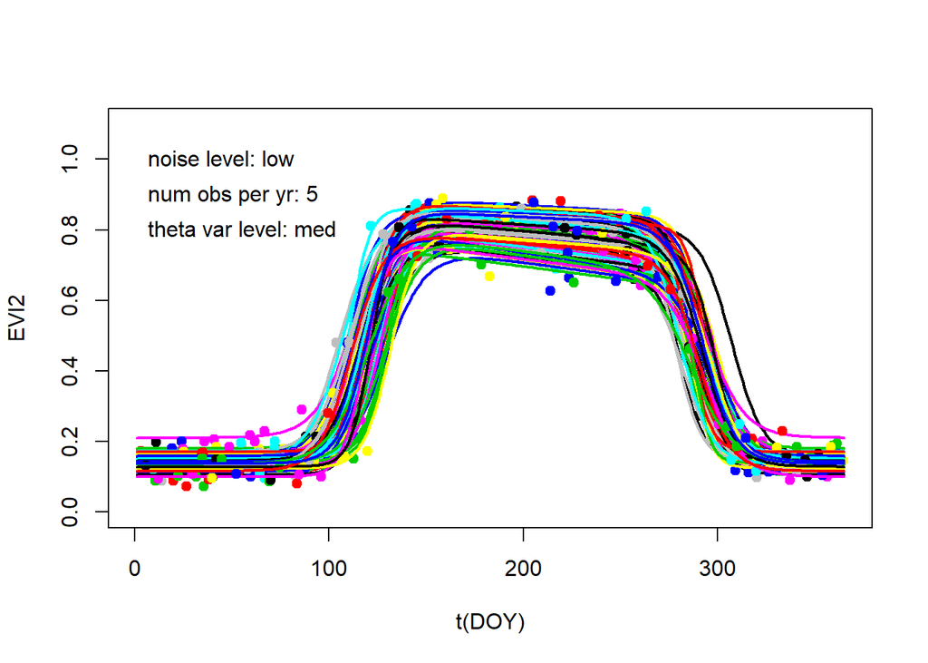

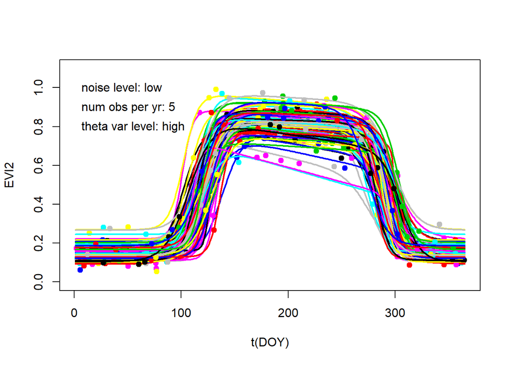

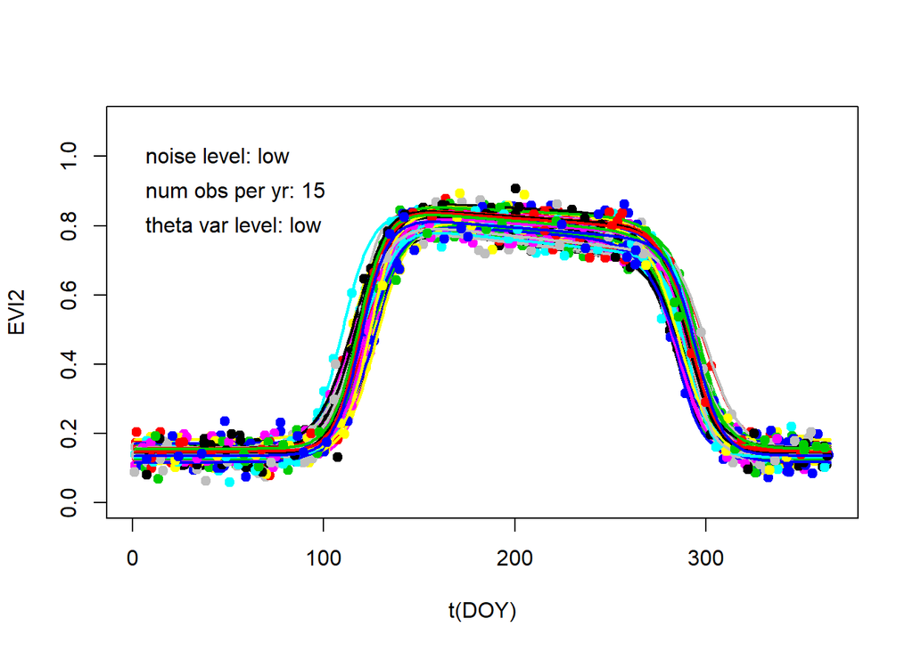

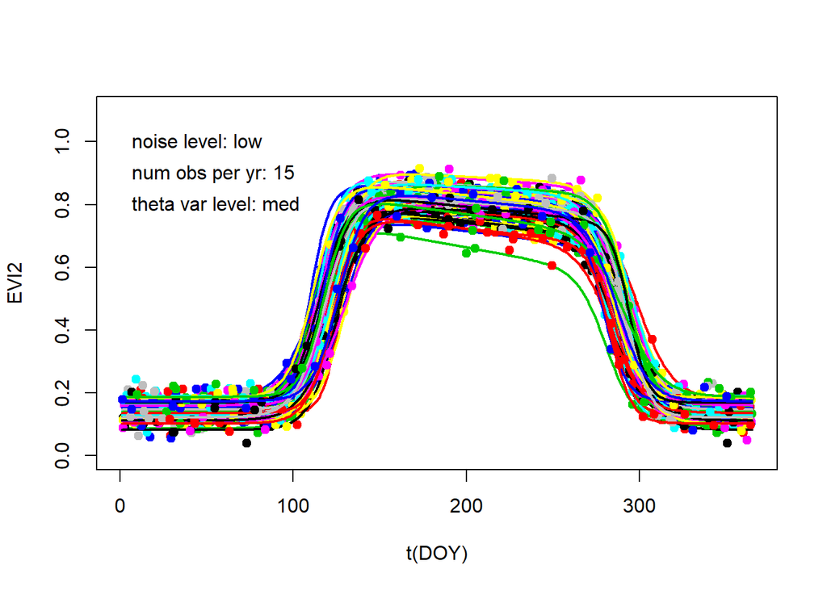

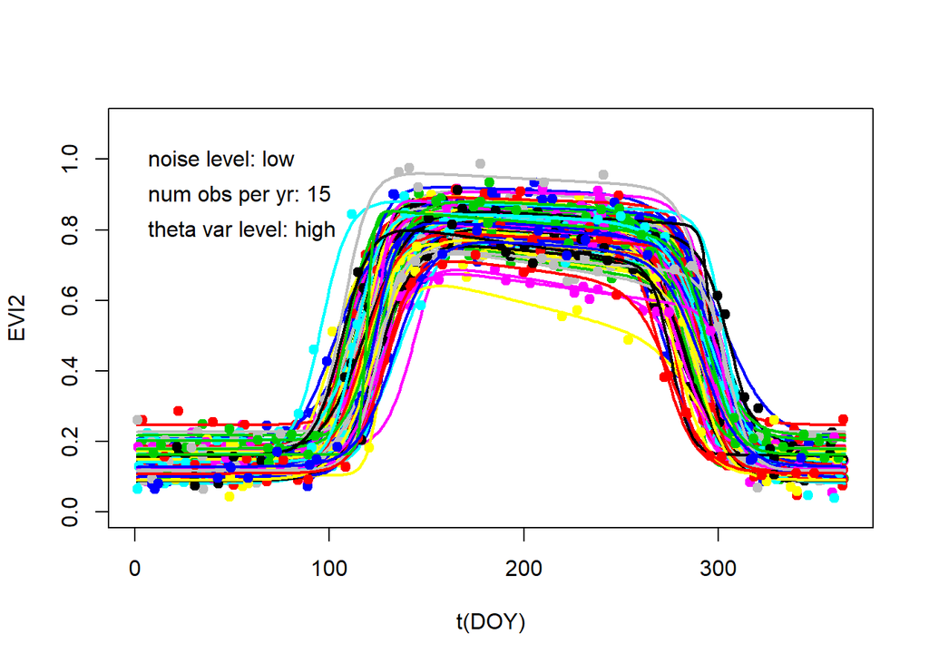

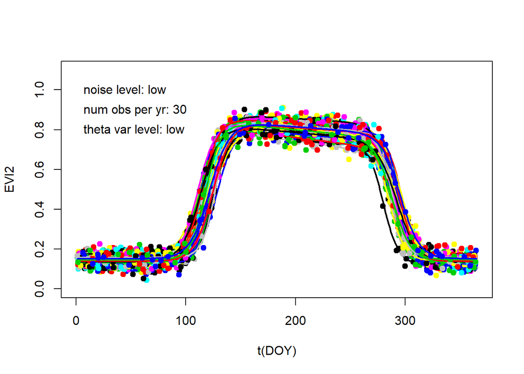

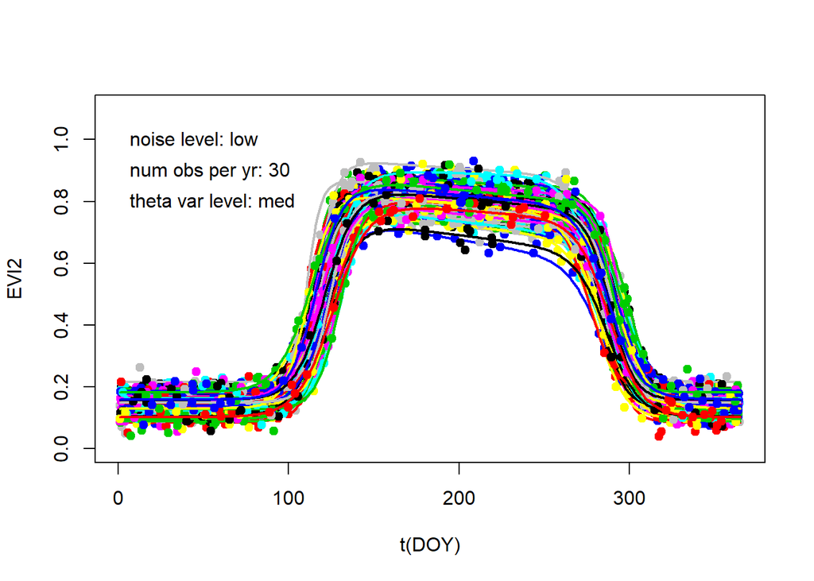

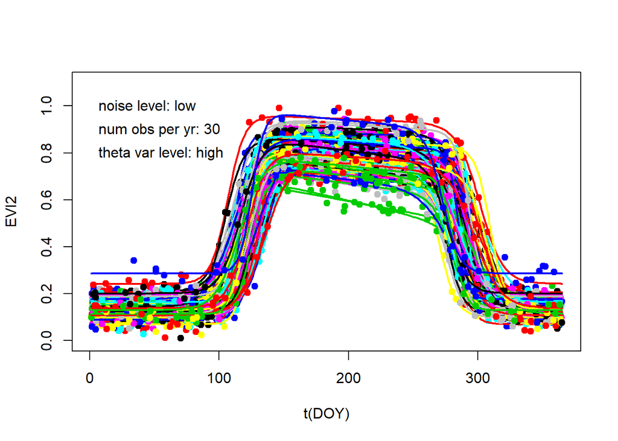

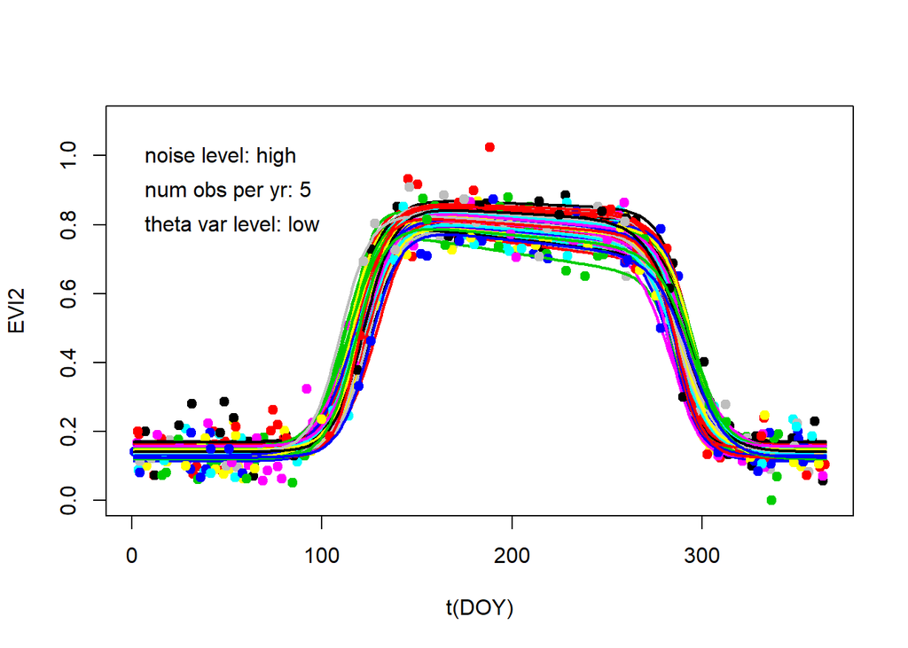

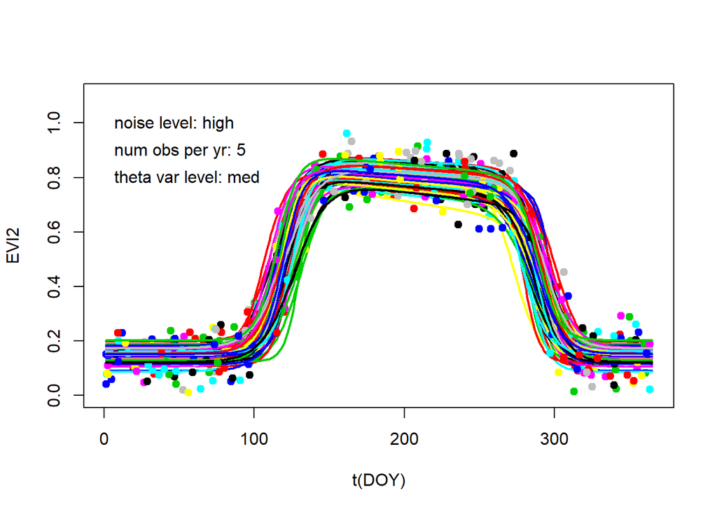

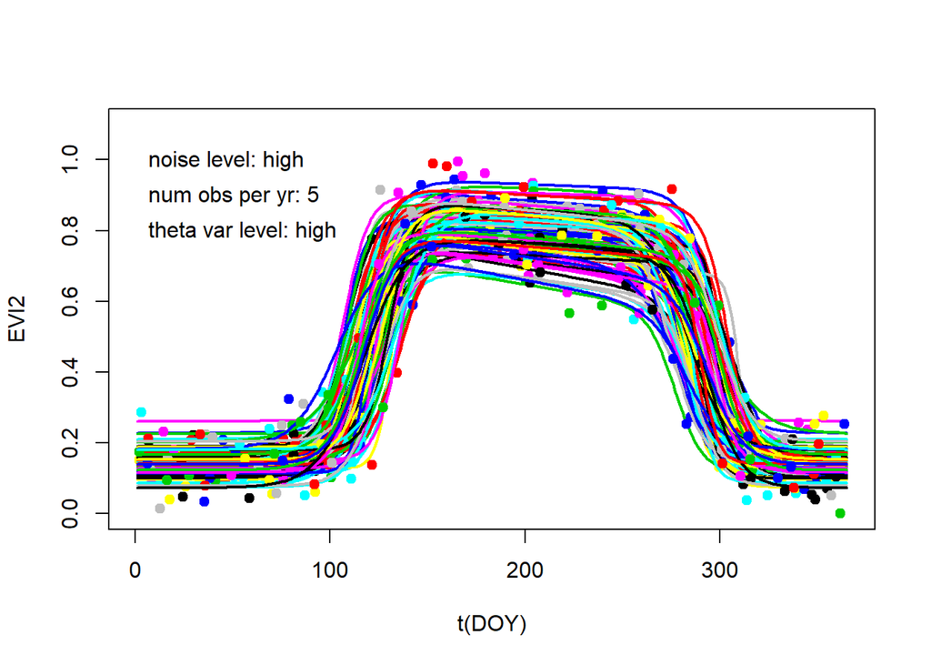

[6 more figures not shown]

```r
sim_theta_mu  <- c(-1.80, 0.75, 120, 8, 290, 8, -7.750)

npar    <- length(sim_theta_mu)
sigma   <- c(0.025, 0.05)
nyear   <- 1000
nobs <- c(5,15,30)

sim_theta_var <- matrix(c( 0.01, 1e-5,  10, 1,  10, 1,  0.05,
                           0.04, 1e-4,  25, 2,  25, 2,  0.1,
                           0.08, 1e-3,  60, 4,  60, 4,  0.2),
                        nrow=3, ncol=npar, byrow=TRUE)

total_combos <- length(sigma)*length(nobs)*nrow(sim_theta_var)
coverages    <- data.frame(matrix(NA, nrow=total_combos, ncol=npar+3))
names(coverages) <- c(paste0("theta", 1:npar), "noise_level", "nobs_level", "theta_var_level")

sos_ci_widths <- matrix(NA, nrow=nyear,ncol=total_combos)
eos_ci_widths <- matrix(NA, nrow=nyear,ncol=total_combos)

sos_devs <- matrix(NA, nrow=nyear,ncol=total_combos)
eos_devs <- matrix(NA, nrow=nyear,ncol=total_combos)

low_high     <- c("low", "high")
low_med_high <- c("low", "med", "high")

index = 1
for(k in 1:2){
  for(j in 1:3){
    for(i in 1:3){
      # simulate the data
      sim <- sim_evi2(sim_theta_mu, sim_theta_var[i,],
                      sigma=sigma[k], nyear=nyear,
                      min_obs = nobs[j], max_obs = nobs[j])

      # plot a fraction of the simualted datasets
      plot_evi2(sim, "parallel", frac=0.1)
      text(0,1, paste("noise level:", low_high[k]), pos=4)
      text(0,0.9, paste("num obs per yr:", nobs[j]), pos=4)
      text(0,0.8, paste("theta var level:", low_med_high[i]), pos=4)

      # create aggregated data set from % sample of simulated years
      sampled_years <- sample(nyear,floor(1*nyear))
      sim_agg <- do.call(rbind, sim$data[sampled_years])

      # construct average model by combining data over years (frequentist non-lin)
      # uses the nlsLM function of the minpack.lm package
      avg_model_over_years <- avg_fit(sim_agg = sim_agg, npar = npar)
      avg_model_theta <- coef(avg_model_over_years)

      # construct the basis functions from the 1st-order Taylor approx
      B <- basis_functions(1:365, avg_model_theta)
      # matplot(B, type = "l")
      # matplot(scale(B), type = "l")

      # priors
      # In this idealized case we assume to know the residual
      # variance and theta covariance.
      V   <- diag(sim_theta_var[i,])
      Q   <- solve(V)
      tau <- 1/sigma[k]^2

      # store results
      theta_hat <- theta_hat_lower <- theta_hat_upper <- sim$theta

      for (year in 1:nyear){

        # construct response and covariate matrix for bayesian regression
        DL_m  <- double_logistic(floor(sim$data[[year]]$t), sim_theta_mu)
        X     <- B[floor(sim$data[[year]]$t),]
        y     <- sim$data[[year]]$y_noise1-DL_m

        # compute posterior mean and covariance
        V <- solve(tau*t(X)%*%X + Q)
        M <- tau*V%*%t(X)%*%(y)

        # estimate theta and 95% credible interval
        theta_hat[year,]       <- avg_model_theta + as.numeric(M)
        theta_hat_lower[year,] <- qnorm(.025, mean=theta_hat[year,], sd=sqrt(diag(V)))
        theta_hat_upper[year,] <- qnorm(.975, mean=theta_hat[year,], sd=sqrt(diag(V)))
      }

      # check if true theta lies within the credible interval
      coverage <- theta_hat_lower<sim$theta & theta_hat_upper>sim$theta
      coverages[index,] <- c(colSums(coverage)/nyear, low_high[k], nobs[j], low_med_high[i])

      # record the widths of the CIs
      sos_ci_widths[,index] <- theta_hat_upper[,3]-theta_hat_lower[,3]
      eos_ci_widths[,index] <- theta_hat_upper[,5]-theta_hat_lower[,5]

      #record the estimated-true value deviation of sos and eos
      sos_devs[,index] <- theta_hat[,3] - sim$theta[,3]
      eos_devs[,index] <- theta_hat[,5] - sim$theta[,5]
      index=index+1
    }
  }
}
```

### Results

```r
coverages[,c(1:4,8:10)]
```

```
##    theta1 theta2 theta3 theta4 noise_level nobs_level theta_var_level
## 1   0.937  0.952  0.937  0.945         low          5             low
## 2   0.932  0.918  0.938  0.923         low          5             med
## 3   0.938   0.92  0.905  0.805         low          5            high
## 4   0.948  0.848  0.931  0.919         low         15             low
## 5   0.922  0.925   0.92  0.866         low         15             med
## 6   0.831  0.944  0.875  0.595         low         15            high
## 7   0.944  0.923  0.932  0.886         low         30             low
## 8   0.905  0.905  0.876  0.773         low         30             med
## 9   0.846  0.956  0.799  0.409         low         30            high
## 10  0.944  0.086  0.942  0.961        high          5             low
## 11  0.943    0.9  0.958  0.846        high          5             med
## 12  0.931  0.919   0.93  0.881        high          5            high
## 13  0.948   0.95  0.947  0.944        high         15             low
## 14  0.938  0.859  0.925  0.907        high         15             med
## 15  0.905  0.942    0.9  0.867        high         15            high
## 16  0.944  0.952  0.935  0.917        high         30             low
## 17  0.943  0.879  0.931  0.883        high         30             med
## 18  0.899  0.923  0.899  0.723        high         30            high
```

```r
coverages[,c(5:7,8:10)]
```

```
##    theta5 theta6 theta7 noise_level nobs_level theta_var_level
## 1   0.932  0.958  0.916         low          5             low
## 2   0.946  0.919  0.857         low          5             med
## 3   0.905  0.798  0.942         low          5            high
## 4   0.944  0.933   0.93         low         15             low
## 5   0.927  0.865  0.918         low         15             med
## 6    0.84  0.703  0.892         low         15            high
## 7    0.93  0.917  0.911         low         30             low
## 8   0.863  0.775  0.924         low         30             med
## 9   0.816   0.48  0.842         low         30            high
## 10  0.941  0.944  0.855        high          5             low
## 11   0.95  0.881  0.924        high          5             med
## 12  0.952  0.894  0.883        high          5            high
## 13  0.938   0.93  0.948        high         15             low
## 14  0.941  0.921  0.963        high         15             med
## 15  0.914  0.846  0.922        high         15            high
## 16   0.94  0.946  0.932        high         30             low
## 17  0.928  0.865  0.944        high         30             med
## 18  0.902  0.755  0.905        high         30            high
```

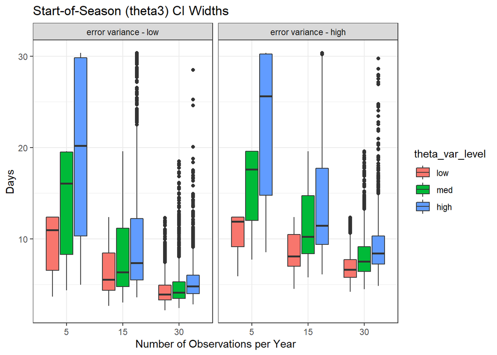

```r
sos_ci_widths <- reformat_sim_data(sos_ci_widths)
eos_ci_widths <- reformat_sim_data(eos_ci_widths)

ggplot(data=sos_ci_widths) +
  geom_boxplot(aes(x=num_obs, y=value, fill=theta_var_level)) +
  facet_grid(~noise_level, labeller = quick_facet_labeller) +
  labs(title = "Start-of-Season (theta3) CI Widths") +
  ylab("Days") +
  xlab("Number of Observations per Year") +
  theme_bw()
```

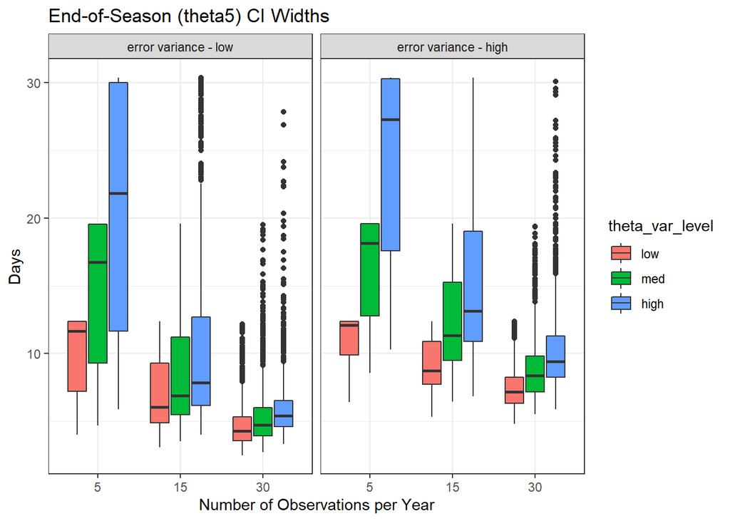

```r
ggplot(data=eos_ci_widths) +
  geom_boxplot(aes(x=num_obs, y=value, fill=theta_var_level)) +
  facet_grid(~noise_level, labeller = quick_facet_labeller) +
  labs(title = "End-of-Season (theta5) CI Widths") +
  ylab("Days") +
  xlab("Number of Observations per Year") +
  theme_bw()
```

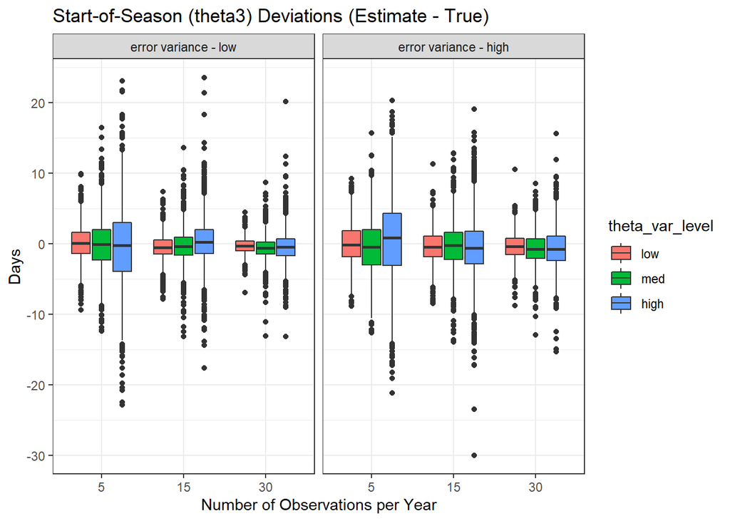

```r
sos_devs <- reformat_sim_data(sos_devs)
eos_devs <- reformat_sim_data(eos_devs)

ggplot(data=sos_devs) +
  geom_boxplot(aes(x=num_obs, y=value, fill=theta_var_level)) +
  facet_grid(~noise_level, labeller = quick_facet_labeller) +
  labs(title = "Start-of-Season (theta3) Deviations (Estimate - True)") +
  ylab("Days") +
  xlab("Number of Observations per Year") +
  theme_bw()
```

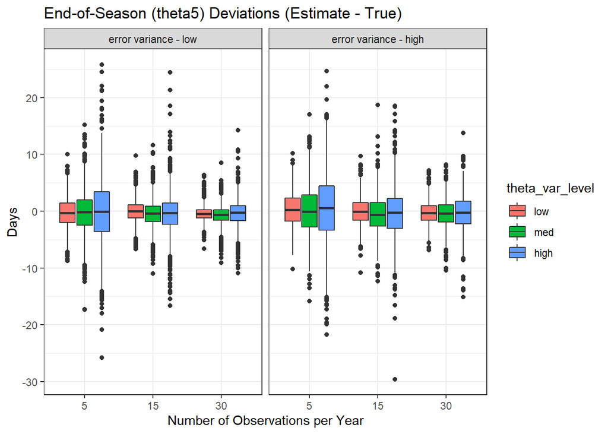

```r
ggplot(data=eos_devs) +
  geom_boxplot(aes(x=num_obs, y=value, fill=theta_var_level)) +
  facet_grid(~noise_level, labeller = quick_facet_labeller) +
  labs(title = "End-of-Season (theta5) Deviations (Estimate - True)") +
  ylab("Days") +
  xlab("Number of Observations per Year") +
  theme_bw()
```